# Multi-Proxy, Multi-Season Streamflow Reconstruction with Mass Balance Adjustment

# Introduction

This code repository reproduces the results of the manuscript “Multi-Proxy, Multi-Season Streamflow Reconstruction with Mass Balance Adjustment” by Hung Nguyen, Stefano Galelli, Chenxi Xu, and Brendan Buckley. The manuscript is currently available as a preprint with [DOI: 10.1002/essoar.10504791.1](https://www.essoar.org/doi/10.1002/essoar.10504791.1).

The repository contains all data used in and results produced by the paper. Data are stored in the folder `data/`. R scripts that are used as subroutines are in the folder `R/`. Pre-computed results are stored in the folder `results/`.

The package `mbr`, in which the mass-balance-adjusted regression is implemented, is currently available on GitHub. Before we start, please install it with

```r
install.packages('remotes')
remotes::install_github('ntthung/mbr')
```

Next, we load the necessary packages and utility functions.

```r
source('R/init.R')
source('R/correlation_functions.R')
source('R/input_selection_functions.R')
```

We also use some special fonts for the plots, so we need to load them as well.

We are now ready to proceed with the workflow.

# Data and Preprocessing

## Tree ring proxies

```r
# Read the metadata
crnMeta <- fread('data/crnMeta.csv', key = 'site') # Ring width chronologies
oxiMeta <- fread('data/oxiMeta.csv', key = 'site') # Oxygen isotope

# Labelling for plots
oxiLab <- function(s) oxiMeta[s, display]
crnLab <- function(s) crnMeta[s, display]

meta <- rbind(oxiMeta[, .(site, display)], crnMeta[, .(site, display)])
setkey(meta, site)
siteLab <- function(s) meta[s, display]

# Markdown code to make the species displayed in italic
crnMeta[, species := paste0('*', species, '*')]
oxiMeta[, species := paste0('*', species, '*')]

# Some other labelling functions
seasonClass <- fread('data/season_class.csv', key = 'season')
ssnLabBrief <- function(x) seasonClass[x, type]
lambdaLab <- function(x) sapply(x, function(v) paste0('\u03bb = ', v))
dark2 <- RColorBrewer::brewer.pal(3, 'Dark2')[c(2, 1, 3)]
metricLab <- function(x) replace(x, x == 'R2', 'R\u00b2')
to_char_1dp <- function(x) sprintf("%.1f", x)
```

### Map

**Figure 1** was made in QGIS, but we can produce a similar map here with R.

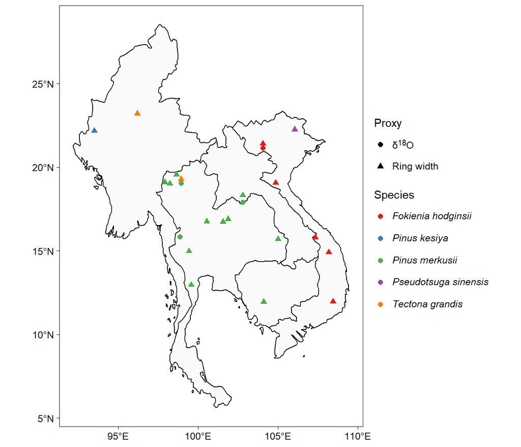

```r
# Map
ggplot() +
  # Country borders
  geom_polygon(
    aes(long, lat, group = group),
    map_data('world', c('Vietnam', 'Laos', 'Cambodia', 'Thailand', 'Myanmar')),
    fill = 'gray98', colour = 'black') +
  # Ring width sites
  geom_point(
    aes(long, lat, colour = species, shape = 'Ring width'),
    size = 2,
    crnMeta) +
  # Oxygen isotope sites
  geom_point(
    aes(long, lat -0.25, colour = species, shape = '&delta;<sup>18</sup>O'),
    size = 2,
    oxiMeta) +
  # Map theming
  scale_x_continuous(name = NULL, labels = pasteLong) +
  scale_y_continuous(name = NULL, labels = pasteLat) +
  scale_colour_brewer(name = 'Species', palette = 'Set1') +
  scale_shape_discrete(name = 'Proxy') +
  coord_quickmap() +
  theme(
    legend.key.height = unit(0.75, 'cm'),
    legend.text = element_markdown()) +
  panel_border('black', 0.2)
```

### Time series

Now we read the proxy data and infill them with the package `missMDA`.

```r
# Read data
oxi <- fread('data/oxi.csv', key = 'site')
crn <- fread('data/crn.csv', key = 'site')

# Count number of years in each chronology
crnCount <- crn[year %in% 1748:2005, .(first = year[1], final = year[.N], .N), by = site
              ][order(N, decreasing = TRUE)
              ][, ID := .GRP, by = site]
oxiCount <- oxi[year %in% 1748:2005, .(first = year[1], final = year[.N], .N), by = site
              ][order(N, decreasing = TRUE)
              ][, ID := .GRP, by = site]

# Imputation
crnWideFull   <- crn[year %in% 1748:2005, dcast(.SD, year ~ site, value.var = 'rwi')]
crnMatFull    <- as.matrix(crnWideFull[, -'year'])
crnImpModel   <- imputePCA(crnMatFull, ncp = 19)
crnMatFilled  <- crnImpModel$completeObs
crnWideFilled <- as.data.table(crnMatFilled)

attributes(crnImpModel$fittedX) <- attributes(crnImpModel$completeObs)
crnPcaImputed <-
  as.data.table(crnImpModel$fittedX)[, year := crnWideFull$year] %>%
  melt(id.var = 'year', variable.name = 'site', value.name = 'X')

oxiWideFull   <- oxi[year %in% 1748:2005, dcast(.SD, year ~ site, value.var = 'do18')]
oxiMatFull    <- as.matrix(oxiWideFull[, -'year'])
oxiImpModel   <- imputePCA(oxiMatFull, ncp = 3)
oxiMatFilled  <- oxiImpModel$completeObs
oxiWideFilled <- as.data.table(oxiMatFilled)

attributes(oxiImpModel$fittedX) <- attributes(oxiImpModel$completeObs)
oxiPcaImputed <-
  as.data.table(oxiImpModel$fittedX)[, year := oxiWideFull$year] %>%
  melt(id.var = 'year', variable.name = 'site', value.name = 'X')
```

**Figure S5**

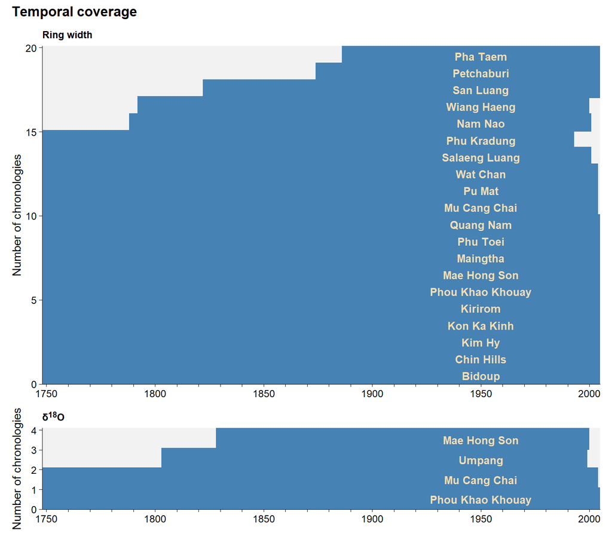

```r
crnSpan <- ggplot(crnCount) +
  geom_rect(
    aes(xmin = first, xmax = final, ymin = ID - 1, ymax = ID + 0.1),
    fill = 'steelblue') +
  geom_text(
    aes(1950, ID - 0.5, label = crnLab(site)),
    colour = 'wheat',
    fontface = 'bold',
    size = 3.5) +
  scale_x_continuous(expand = c(0, 0), breaks = seq(1750, 2005, 10), labels = skip_label(5)) +
  scale_y_continuous(expand = c(0, 0)) +
  labs(x = NULL, y = 'Number of chronologies', subtitle = 'Ring width') +
  theme(
    plot.subtitle = element_text(face = 'bold'),
    panel.background = element_rect('gray95'),
    panel.grid = element_blank())
oxiSpan <- ggplot(oxiCount) +
  geom_rect(
    aes(xmin = first, xmax = final, ymin = ID - 1, ymax = ID + 0.1), fill = 'steelblue') +
  geom_text(
    aes(1950, ID - 0.5, label = oxiLab(site)),
    colour = 'wheat',
    fontface = 'bold',
    size = 3.5) +
  scale_x_continuous(expand = c(0, 0), breaks = seq(1750, 2005, 10), labels = skip_label(5)) +
  scale_y_continuous(expand = c(0, 0)) +
  labs(x = NULL, y = 'Number of chronologies', subtitle = '&delta;<sup>18</sup>O') +
  theme(
    plot.subtitle = element_markdown(face = 'bold'),
    panel.background = element_rect('gray95'),
    panel.grid = element_blank())

crnSpan + oxiSpan +
  plot_layout(heights = c(5, 1.2)) +
  plot_annotation(title = 'Temporal coverage')
```

**Figure S6**

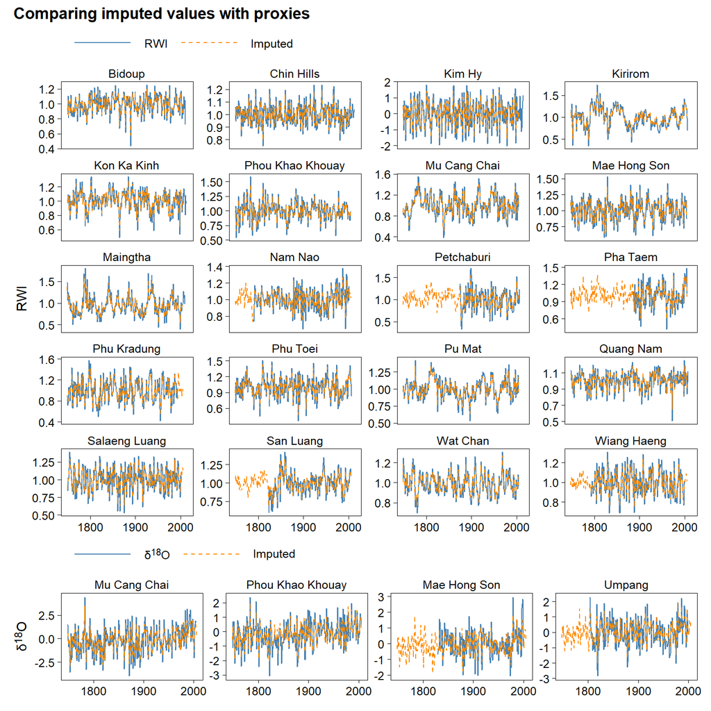

```r
crnImpPlot <- ggplot() +
  geom_line(aes(year, rwi, colour = 'RWI', linetype = 'RWI'), crn[year >= 1748]) +
  geom_line(aes(year, X, colour = 'Imputed', linetype = 'Imputed'), crnPcaImputed) +
  scale_colour_manual(
    name = NULL,
    breaks = c('RWI', 'Imputed'),
    values = c('steelblue', 'darkorange')) +
  scale_linetype_manual(
    name = NULL,
    breaks = c('RWI', 'Imputed'),
    values = c(1, 2)) +
  facet_wrap(
    vars(site),
    labeller = as_labeller(crnLab),
    ncol = 4,
    scales = 'free_y') +
  labs(x = NULL, y = 'RWI')

oxiImpPlot <- ggplot() +
  geom_line(
    aes(year, do18, colour = '&delta;<sup>18</sup>O', linetype = '&delta;<sup>18</sup>O'),
    oxi[year >= 1748]) +
  geom_line(
    aes(year, X, colour = 'Imputed', linetype = 'Imputed'),
    oxiPcaImputed) +
  scale_colour_manual(
    name = NULL,
    breaks = c('&delta;<sup>18</sup>O', 'Imputed'),
    values = c('steelblue', 'darkorange')) +
  scale_linetype_manual(
    name = NULL,
    breaks = c('&delta;<sup>18</sup>O', 'Imputed'),
    values = c(1, 2)) +
  facet_wrap(
    vars(site),
    labeller = as_labeller(oxiLab),
    ncol = 4,
    scales = 'free_y') +
  labs(x = NULL, y = '&delta;<sup>18</sup>O') +
  theme(
    axis.title.y = element_markdown(),
    legend.text = element_markdown())

pl <- crnImpPlot + oxiImpPlot &
  theme(
    strip.background = element_blank(),
    strip.text = element_text(face = 'plain'),
    legend.position = 'top',
    legend.key.width = unit(2, 'cm'),
    panel.border = element_rect(NA, 'black', 0.2))
pl +
  plot_layout(ncol = 1, heights = c(5, 1)) +
  plot_annotation(title = 'Comparing imputed values with proxies')
```

## Streamflow

### Exploring monthly streamflow

**Figure S1**

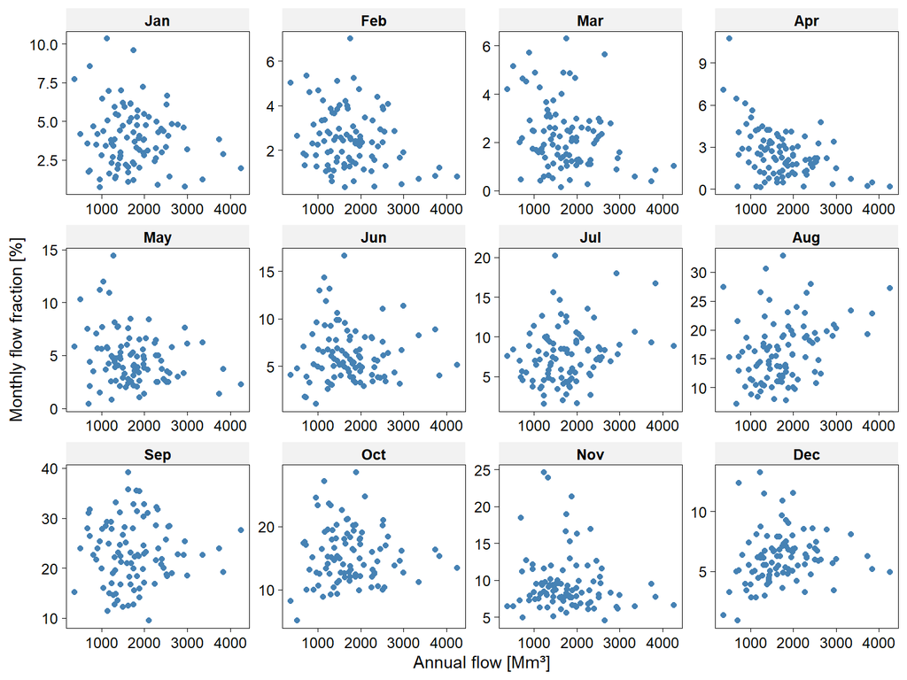

```r
p1m <- fread('data/P1-monthly.csv')
p1m[, Qa := sum(Qm), by = year]
ggplot(p1m[year %in% 1922:2016]) +
  geom_point(aes(Qa, Qm / Qa * 100), colour = 'steelblue') +
  facet_wrap(
    vars(month),
    labeller = as_labeller(monthLab),
    ncol = 4,
    scales = 'free') +
  labs(x = 'Annual flow [Mm\u00b3]', y = 'Monthly flow fraction [%]') +
  panel_border('black', 0.2)
```

**Figure 1c**

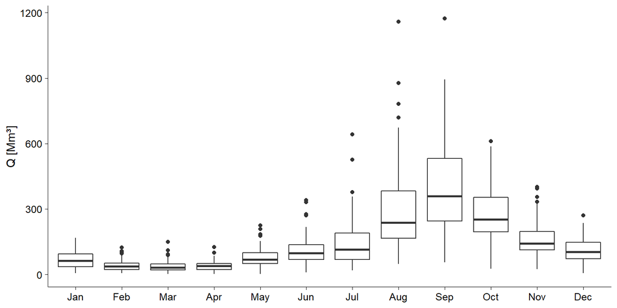

```r
ggplot(p1m) +
  geom_boxplot(aes(factor(month, labels = month.abb), Qm)) +
  labs(x = NULL, y = 'Q [Mm\u00b3]')
```

### Season delineation

Read daily data.

```r
p1d <- fread('data/P1-daily-raw.csv')
# Calculate day of the year
p1d[, doy := {
  date <- paste(year, month, day, sep = '-') %>% as.Date(format = c('%Y-%B-%d'))
  yday(date)
}]
# Ignore leap days
p1d <- p1d[!(year %% 4 == 0 & doy == 60)]
p1d[year %% 4 == 0 & doy > 59, doy := doy - 1]

# Convert flow rate to volumetric (m3/s to million m3 each day)
p1d[, Qv := cumsum(Q * 0.0864), by = year]
p1dfy <- p1d[year %in% 1922:2016] # Full years
setkey(p1dfy, year, doy)
```

Two-phase linear regression, following Cook and Buckley (2009).

```r
# Changepoint functions
ssq_left_right <- function(x, t.range, d) {
  idx1 <- which(t.range <= d)
  idx2 <- which(t.range >  d)
  t1   <- matrix(c(rep(1, length(idx1)), t.range[idx1]), ncol = 2)
  t2   <- matrix(c(rep(1, length(idx2)), t.range[idx2]), ncol = 2)
  left  <- .lm.fit(t1, x[idx1])$residuals
  right <- .lm.fit(t2, x[idx2])$residuals
  sum(left^2) + sum(right^2)
}

# doy.range: vector of days of the year, must be contiguous
scan_2lr <- function(DT, doy.range, scan.range, var.name) {
  dt <- DT[doy %in% doy.range]
  x <- dt[, get(var.name)]
  ssq <- sapply(scan.range, ssq_left_right, x = x, t.range = doy.range)
  data.table(doy = scan.range, ssq = ssq)
}

summary_2lr <- function(ssq) ssq[which.min(ssq)][, date := doy_to_ddMMM(doy)][]

plot_2lr <- function(ssq, nudge_y = 2) {
  changeDate <- summary_2lr(ssq)
  ggplot(ssq, aes(doy, ssq)) +
    geom_line(colour = 'steelblue') +
    geom_point(data = changeDate, colour = 'steelblue') +
    geom_text(aes(label = date), changeDate, nudge_y = nudge_y) +
    labs(x = 'Day of year', y = 'RSS') +
    theme_classic()
}
dryRange <- seq(  1, 280)
dryScan  <- seq( 51, 270)
wetRange <- seq(220, 365)
wetScan  <- seq(230, 355)
d2wAnn <- p1dfy[, summary_2lr(scan_2lr(.SD, dryRange, dryScan, 'Qv')), by = year]
w2dAnn <- p1dfy[, summary_2lr(scan_2lr(.SD, wetRange, wetScan, 'Qv')), by = year]
annualWetSeason <- merge(d2wAnn[, .(year, doy, date)], w2dAnn[, .(year, doy, date)],
                         by = 'year',
                         suffixes = c('sta', 'fin'))
```

**Figure S2**

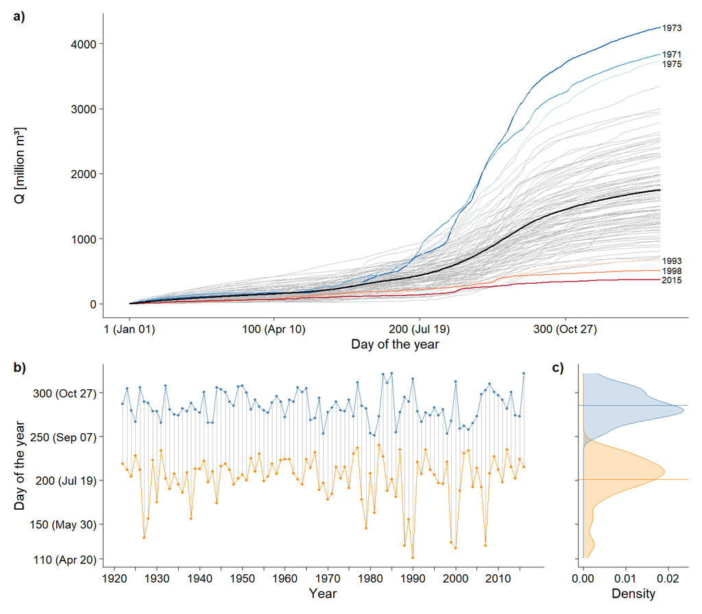

```r
Qtails <- p1dfy[, last(.SD), by = year
              ][order(Qv), rbind(head(.SD, 3), last(.SD, 3))]
yearOrder <- Qtails$year
cumuPlot <- ggplot(p1dfy) +
  geom_line(aes(doy, Qv, group = year), na.rm = TRUE, colour = 'gray', size = 0.2) +
  geom_line(
    aes(doy, Qv, group = year, colour = factor(year, levels = yearOrder)),
    p1d[year %in% Qtails$year],
    size = 0.4, show.legend = FALSE) +
  geom_text(
    aes(366, Qv, label = year),
    Qtails,
    vjust = c(0.5, 0.5, 0.5, 0.9, 0.5, 0.5),
    hjust = 0,
    size = 2.5) +
  stat_summary(aes(doy, Qv), fun = mean, geom = 'line', na.rm = TRUE, size = 0.6) +
  scale_x_continuous(breaks = c(1, 100, 200, 300), labels = doy_month_label) +
  scale_colour_brewer(palette = 'RdBu') +
  labs(x = 'Day of the year', y = 'Q [million m\u00b3]')

p1 <- ggplot(annualWetSeason) +
  geom_linerange(aes(year, ymin = doysta, ymax = doyfin), colour = 'gray', size = 0.2) +
  geom_line(aes(year, doysta), size = 0.2, colour = 'darkorange') +
  geom_line(aes(year, doyfin), size = 0.2, colour = 'steelblue') +
  geom_point(aes(year, doysta), size = 0.7, colour = 'darkorange') +
  geom_point(aes(year, doyfin), size = 0.7, colour = 'steelblue') +
  scale_colour_manual(name = NULL, values = c('darkgreen', 'steelblue')) +
  scale_x_continuous(breaks = seq(1920, 2015, 5),
                     labels = function(x) ifelse(x %% 10 == 0, x, '')) +
  scale_y_continuous(breaks = c(110, seq(100, 300, 50)), labels = doy_month_label) +
  labs(x = 'Year', y = 'Day of the year') +
  theme(legend.position = 'none')
p2 <- ggplot(annualWetSeason) +
  geom_density(
    aes(y = doysta),
    size = 0.3,
    colour = 'darkorange',
    fill = 'darkorange',
    alpha = 0.25) +
  geom_density(
    aes(y = doyfin),
    size = 0.3,
    colour = 'steelblue',
    fill = 'steelblue',
    alpha = 0.25) +
  geom_hline(aes(yintercept = mean(doysta)), size = 0.2, colour = 'darkorange') +
  geom_hline(aes(yintercept = mean(doyfin)), size = 0.2, colour = 'steelblue') +
  scale_x_continuous(breaks = scales::pretty_breaks(2)) +
  scale_y_continuous(breaks = c(110, seq(100, 300, 50))) +
  labs(x = 'Density', y = NULL) +
  theme(
    plot.tag.position = c(-0.2, 1),
    plot.margin = margin(l = 20),
    axis.text.y = element_blank())

delinPlot <- p1 + p2 +
  plot_layout(widths = c(4, 1))

wrap_plots(cumuPlot) + wrap_plots(delinPlot) +
  plot_layout(ncol = 1, heights = c(1.5, 1)) +
  plot_annotation(tag_levels = 'a', tag_suffix = ')')
```

### Daily streamflow naturalization

We use robust empirical quantile mapping, following Gudmundsson *et al*. (2012). The procedure is implemented in the package `qmap` (Gudmundsson, 2016). See also Robeson *et al.* (2020).

```r
# Merge VIC-Res simulated streamflow to daily streamflow
p1MergeDaily <- merge(
  p1d[year %in% 1922:2005, .(year, month = match(month, month.abb), day, Qobs = Q)],
  fread('data/P1-VIC-Res.csv'),
  on = c('year', 'month', 'day'))
p1MergeDaily[, period := fifelse(year > 1985, 'Since 1985', 'Before 1985')]

#N aturalize with quantile mapping.
p1MergeDaily[, Qnat := {
  fit <- fitQmap(.SD[period == 'Before 1985', Qobs],
                 .SD[period == 'Before 1985', Qvic],
                 'RQUANT',
                 nlls = 30, wet.day = 0.01, nboot = 100)
  doQmap(.SD[, Qvic], fit)
}, by = month]

# Calculate monthly means
p1Mon <- p1MergeDaily[, lapply(.SD, mean), by = .(year, month, period), .SDcols = -'day']

p1MonLong <- melt(
  p1Mon[period == 'Before 1985', -'period'], # Use data before 1985 only
  id.var = c('year', 'month'),
  variable.name = 'type',
  value.name = 'Q',
  variable.factor = FALSE)

# Calculate volumetric flow
p1DayLong <- melt(
  p1MergeDaily[, -'period'],
  id.var = c('year', 'month', 'day'),
  variable.name = 'type',
  value.name = 'Q',
  variable.factor = FALSE)
p1DayLong[, Q := Q * 3600 * 24 / 1e6]

p1MonVol <- p1DayLong[, .(Q = sum(Q)), by = .(year, month, type)]

# Aggregate to seasonal flows

# First, define the seasons
names(seasons) <- seasons <- c('NJ', 'JO', 'WY')
seasonClass <- fread('data/season_class.csv', key = 'season')
ssnLabBrief <- function(x) seasonClass[x, type]

# Get seasonal total
natSeas <- rbindlist(list(
  NJ = p1MonVol[, get_seasons(.SD, 'Q', 'Qa', c(11:12, 1:6), months.fwd = 11:12), by = type],
  JO = p1MonVol[, get_seasons(.SD, 'Q', 'Qa', 7:10), by = type],
  WY = p1MonVol[, get_seasons(.SD, 'Q', 'Qa', 1:12, months.fwd = 11:12), by = type]),
  idcol = 'season')

natSeas[, type := fcase(type == 'Qvic', 'Uncorrected',
                        type == 'Qobs', 'Observed',
                        type == 'Qnat', 'Bias-corrected')]
natSeas[, season := factor(season, seasons)]
```

**Figure S3**

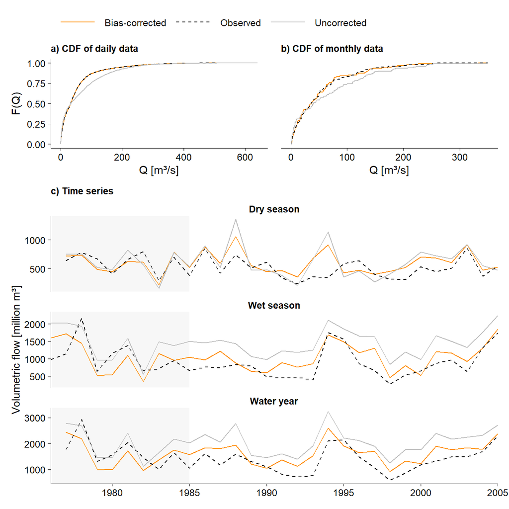

```r
Qx <- seq(min(p1MonLong$Q), max(p1MonLong$Q), length.out = 1000)
cdf <- p1MonLong[, .(Q = Qx, FQ = ecdf(Q)(Qx)), by = type]

cdf[, type := fcase(type == 'Qvic', 'Uncorrected',
                    type == 'Qobs', 'Observed',
                    type == 'Qnat', 'Bias-corrected')]

monCDFcomm <- ggplot(cdf, aes(Q, FQ, colour = type, linetype = type)) +
  geom_line() +
  scale_colour_manual(name = NULL, values = c('darkorange', 'black', 'gray')) +
  scale_linetype_manual(name = NULL, values = c(1, 2, 1)) +
  labs(x = 'Q [m\u00b3/s]', y = 'F(Q)') +
  labs(subtitle = 'b) CDF of monthly data')

DT <- melt(p1MergeDaily[period == 'Before 1985', -'period'],
           id.var = c('year', 'month', 'day'),
           variable.name = 'type',
           value.name = 'Q',
           variable.factor = FALSE)
Qx <- seq(min(DT$Q), max(DT$Q), length.out = 1000)
cdf <- DT[, .(Q = Qx, FQ = ecdf(Q)(Qx)), by = type]
cdf[, type := fcase(type == 'Qvic', 'Uncorrected',
                    type == 'Qobs', 'Observed',
                    type == 'Qnat', 'Bias-corrected')]

dayCDF <- ggplot(cdf, aes(Q, FQ, colour = type, linetype = type)) +
  geom_line() +
  scale_colour_manual(name = NULL, values = c('darkorange', 'black', 'grey')) +
  scale_linetype_manual(name = NULL, values = c(1, 2, 1)) +
  labs(x = 'Q [m\u00b3/s]', y = 'F(Q)') +
  labs(subtitle = 'a) CDF of daily data')

tsPlot <- ggplot(natSeas) +
  geom_rect(aes(xmin = 1976, xmax = 1985, ymin = -Inf, ymax = Inf), fill = 'gray97') +
  geom_line(aes(year, Qa, colour = type, linetype = type)) +
  facet_wrap(vars(season), scales = 'free_y', ncol = 1, labeller = as_labeller(ssnLabBrief)) +
  scale_linetype_manual(name = NULL, values = c(1, 2, 1)) +
  scale_colour_manual(name = NULL, values = c('darkorange', 'black', 'grey')) +
  scale_x_continuous(
    expand = c(0, 0),
    breaks = seq(1975, 2005, 5)) +
  labs(
    subtitle = 'c) Time series',
    x = NULL,
    y = 'Volumetric flow [million m\u00b3]')

layout <- '
DDDD
AABB
AABB
AABB
AABB
CCCC
CCCC
CCCC
CCCC
CCCC
CCCC
CCCC
CCCC
CCCC
CCCC
CCCC
CCCC
'

monCDFcomm <- monCDFcomm +
  theme(axis.text.y = element_blank(),
        axis.title.y = element_blank(),
        axis.line.y = element_blank(),
        axis.ticks.y = element_blank())

pl <- dayCDF + monCDFcomm + tsPlot + guide_area() &
  theme(
    strip.background = element_blank(),
    plot.subtitle = element_text(face = 'bold'),
    legend.key.width = unit(1.5, 'cm'),
    legend.position = 'top')
pl + plot_layout(design = layout, guides = 'collect')
```

### Combine flow

```r
# Seasonal observed flow from 1922 to 1985
p1s <- rbindlist(list(
  NJ = get_seasons(p1m, 'Qm', 'Qa', c(11:12, 1:6), months.fwd = 11:12),
  JO = get_seasons(p1m, 'Qm', 'Qa', 7:10),
  WY = get_seasons(p1m, 'Qm', 'Qa', 1:12, months.fwd = 11:12) # New water year, Nov - Oct
), idcol = 'season')[year %in% 1922:1984]
p1s[, season := factor(season, levels = seasons)]
setkey(p1s, season)

# Naturalized seasonal flow from 1986 to 2005
p1merge <- rbind(
  p1s,
  natSeas[type == 'Bias-corrected' & year >= 1985, -'type'])
p1merge[, season := factor(season, seasons)]
setkey(p1merge, season)

# Target: 1922:2003
p1tar <- p1merge[year %in% 1922:2003]

## Hinkley D and transformation type
p1HD <- p1merge[, .(D   = round(hinkley(Qa), 2),
                    Dlog = round(hinkley(log(Qa)), 2)),
                keyby = season
              ][, trans := fifelse(abs(D) > abs(Dlog), 'log', 'none')]
```

**Table S1.** Flow transformation type.

```r
p1HD[]
```

```
##    season    D  Dlog trans
## 1:     NJ 0.13  0.01   log
## 2:     JO 0.15 -0.01   log
## 3:     WY 0.12  0.00   log
```

**Figure S4**

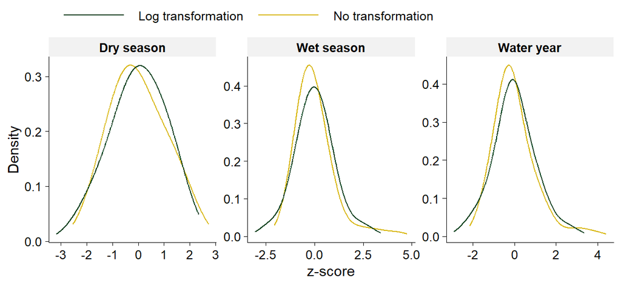

```r
instDens <- p1tar[, {
  bw <- if (.BY$season == 'NJ') 0.7 else 0.5
  d1 <- density(standardize(Qa), bw = bw, cut = 1)
  d2 <- density(standardize(log(Qa)), bw = bw, cut = 1)
  c(list(x0 = d1$x, y0 = d1$y, xlog = d2$x, ylog = d2$y))
}, by = season]

ggplot(instDens) +
  geom_line(aes(x0, y0, colour = 'No transformation')) +
  geom_line(aes(xlog, ylog, colour = 'Log transformation')) +
  scale_colour_manual(
    name = NULL,
    values = pal) +
  facet_wrap(
    vars(season),
    labeller = as_labeller(ssnLabBrief),
    scales = 'free') +
  labs(x = 'z-score', y = 'Density') +
  theme(
    strip.background = element_rect('gray95', NA),
    legend.key.width = unit(2, 'cm'),
    legend.position = 'top')
```

So all targets need to be log-transformed.

# Correlation analyses

## Streamflow-proxy correlations

Bootstrapped correlations.

```r
# Core years: 1750:2003, and shift back or forth
crnLags <- -2:2 # All lags for ring width
oxiLags <- 0:2  # Positive lags only for d18O

# Input matrices
Xrw <- do.call(cbind, lapply(crnLags, function(l) {
  x <- crnMatFilled[3:256 - l, ]
  colnames(x) <- paste0(colnames(x), l)
  x
}))
Xdo <- do.call(cbind, lapply(oxiLags, function(l) {
  x <- oxiMatFilled[3:256 - l, ]
  colnames(x) <- paste0(colnames(x), l)
  x
}))
Xrwdo <- cbind(Xrw, Xdo)

# Streamflow target: 1922 to 2003
QMat    <- log(as.matrix(dcast(p1tar, year ~ season, value.var = 'Qa')[, -'year']))
cor_lag <- function(X, Y, l, Xyears, Yyears, alpha) {
  ind <- which(Xyears %in% Yyears) - l
  cor_boot(cbind(X[ind, ], Y),
           1:ncol(X),
           1:ncol(Y) + ncol(X),
           c('site', 'season'),
           alpha = alpha)
}

set.seed(42)
rhoCrn <- lapplyrbind(crnLags, function(l) {
    DT <- cor_lag(crnMatFilled, QMat, l, 1748:2005, 1922:2003, 0.05)
    DT[, lag := l]
    DT[, alpha := 0.05][]
  })
rhoOxi <- lapplyrbind(oxiLags, function(l) {
    DT <- cor_lag(oxiMatFilled, QMat, l, 1748:2005, 1922:2003, 0.05)
    DT[, lag := l]
    DT[, alpha := 0.05][]
  })

dt <- CJ(s = factor(seasons, seasons), l = crnLags)
dt[, sl := paste0(s, '(', l, ')')]

rhoCrn[, season_lag := paste0(season, '(', lag, ')')]
rhoCrn[, season_lag := factor(season_lag, levels = dt$sl)]
rhoCrn[, season := factor(season, levels = seasons)]
rhoCrn[, lag := factor(lag, levels = crnLags)]

rhoOxi[, season_lag := paste0(season, '(', lag, ')')]
rhoOxi[, season_lag := factor(season_lag, levels = dt$sl)]
rhoOxi[, season := factor(season, levels = seasons)]
rhoOxi[, lag := factor(lag, levels =crnLags)]
```

**Figure 2**

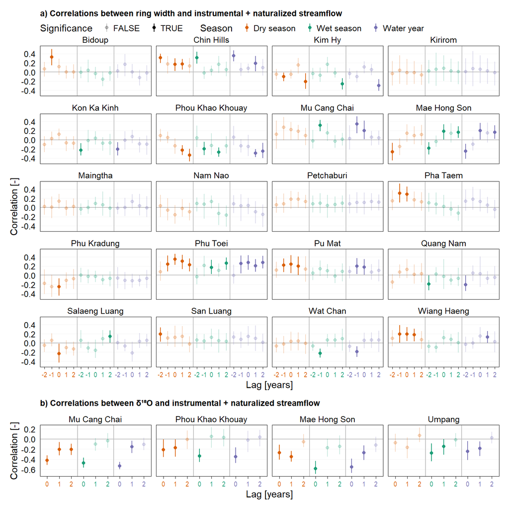

```r
ssnLabLag <- function(x) {
  char <- sapply(x, substr, start = 1, stop = 2)
  yr <- sapply(x, function(xx) {
    c1 <- substr(xx, 4, 4)
    if (c1 == '-') c1 <- substr(xx, 4, 5)
    c1
  })
  fcase(
    char == 'NJ', paste0('<span style="color:', dark2[1], '">', yr, '</span>'),
    char == 'JO', paste0('<span style="color:', dark2[2], '">', yr, '</span>'),
    char == 'WY', paste0('<span style="color:', dark2[3], '">', yr, '</span>')
  )
}

p1 <- ggplot(rhoCrn) +
  geom_hline(yintercept = 0, colour = 'gray') +
  geom_vline(
    xintercept = c(length(crnLags) + 0.5, length(crnLags) * 2 + 0.5),
    colour = 'gray') +
  geom_linerange(aes(season_lag, ymin = low, ymax = high, alpha = signif, colour = season)) +
  geom_point(aes(season_lag, median, alpha = signif, colour = season)) +
  scale_colour_manual(name = 'Season', values = dark2, labels = ssnLabBrief) +
  facet_wrap(vars(site), labeller = as_labeller(crnLab), ncol = 4) +
  scale_alpha_manual(name = 'Significance', values = c(0.25, 1)) +
  scale_x_discrete(labels = ssnLabLag) +
  scale_y_continuous(breaks = c(-0.6, -0.4, -0.2, 0, 0.2, 0.4, 0.6)) +
  labs(
    x = 'Lag [years]', y = 'Correlation [-]',
    subtitle = 'a) Correlations between ring width and instrumental + naturalized streamflow') +
  theme(axis.text.x = ggtext::element_markdown(family = 'Arial Narrow', size = 8),
        axis.ticks.y = element_blank(),
        axis.line = element_line(size = 0.1),
        axis.ticks.x = element_line(size = 0.1),
        legend.key.width = unit(0.1, 'cm'),
        legend.text = element_text(margin = margin(r = 0.3, unit = 'cm')),
        legend.title = element_text(margin = margin(r = 0.3, unit = 'cm')),
        legend.position = 'top',
        legend.box.spacing = unit(-0.3, 'cm'),
        panel.grid.major.y = element_line('gray95', 0.1),
        panel.border = element_rect(NA, 'black', 0.1),
        strip.text = element_text(face = 'plain'),
        strip.background = element_blank(),
        plot.subtitle = element_text(face = 'bold'))
p2 <- ggplot(rhoOxi) +
  geom_hline(yintercept = 0, colour = 'gray') +
  geom_vline(
    xintercept = c(length(oxiLags) + 0.5, length(oxiLags) * 2 + 0.5),
    colour = 'gray') +
  geom_linerange(aes(season_lag, ymin = low, ymax = high, alpha = signif, colour = season)) +
  geom_point(aes(season_lag, median, alpha = signif, colour = season)) +
  facet_wrap(vars(site), labeller = as_labeller(oxiLab), nrow = 1) +
  scale_colour_manual(name = 'Season', values = dark2, labels = ssnLabBrief) +
  scale_alpha_manual(name = 'Significance', values = c(0.25, 1)) +
  scale_x_discrete(labels = ssnLabLag) +
  scale_y_continuous(breaks = c(-0.6, -0.4, -0.2, 0, 0.2, 0.4, 0.6)) +
  labs(
    x = 'Lag [years]', y = 'Correlation [-]',
    subtitle = 'b) Correlations between \u03b4\u00b9\u2078O and instrumental + naturalized streamflow') +
  theme(axis.text.x = ggtext::element_markdown(family = 'Arial Narrow', size = 8),
        axis.ticks.y = element_blank(),
        axis.ticks.x = element_line(size = 0.1),
        axis.line = element_line(size = 0.1),
        panel.grid.major.y = element_line('gray95', 0.1),
        panel.border = element_rect(NA, 'black', 0.1),
        legend.position = 'none',
        strip.text = element_text(face = 'plain'),
        strip.background = element_blank(),
        plot.subtitle = element_text(face = 'bold'))

p1 / p2 + plot_layout(heights = c(6.25, 1))
```

## Proxy-climate correlations

We calculate the correlations between tree rings and CRU TS-4.04 precipitation data (Harris *et al.*, 2020). Here we provide a subset of the CRU data set that contains only the grid points in Southeast Asia.

```r
pre <- readRDS('data/CRU-precip.RDS')
preMS <- pre[month %in% 7:10, .(pre = sum(pre)), by = .(lon, lat, year)]
preMAM <- pre[month %in% 3:5, .(pre = sum(pre)), by = .(lon, lat, year)]
preMS.sd <- preMS[, .(sd = sd(pre)), by = .(lon, lat)][sd < 0.1]
setkey(preMS, lon, lat)
setkey(preMS.sd, lon, lat)
preMS <- preMS[!preMS.sd]

corMS <- grid_cor(crn, preMS, 'rwi', 'pre', crnMeta)
corMAM <- grid_cor(crn, preMAM, 'rwi', 'pre', crnMeta)

corOxiMS <- grid_cor(oxi, preMS, 'do18', 'pre', oxiMeta)
corOxiMAM <- grid_cor(oxi, preMAM, 'do18', 'pre', oxiMeta)
```

### Tree rings

**Figure S7**

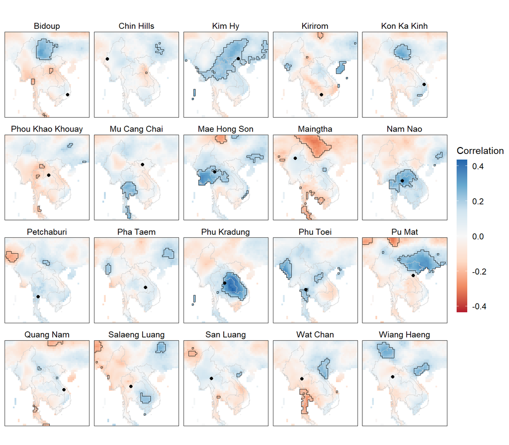

```r
plot_cor(corMS)
```

**Figure S8**

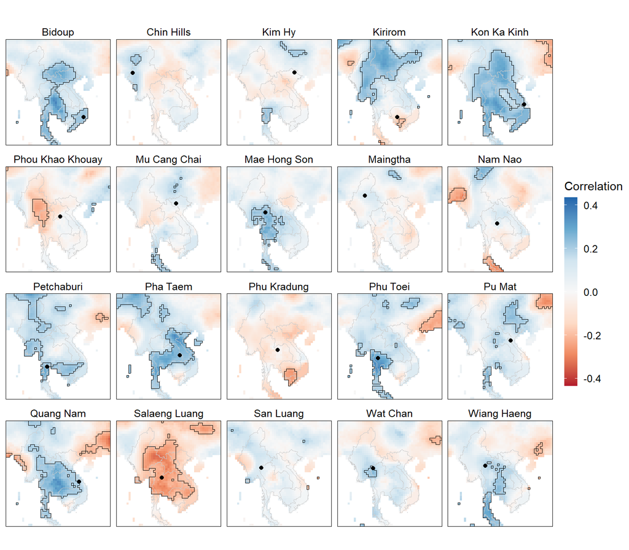

```r
plot_cor(corMAM, cor.limits = abs_range(corMS$rho$r))
```

### Oxygen isotope

**Figure S9**

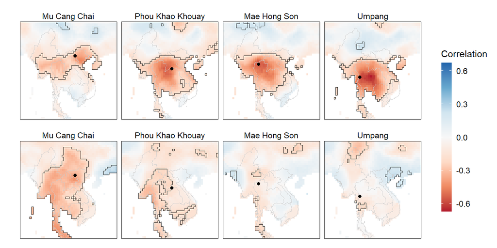

```r
p1 <- plot_cor(corOxiMS)
p2 <- plot_cor(corOxiMAM, cor.limits = abs_range(corOxiMS$rho$r))
p1 + p2 +
  plot_layout(ncol = 1, guides = 'collect')
```

# Reconstruction

## Site selection

Number of potential inputs for each season

```r
allInputs <- rbind(rhoCrn[{signif}, .(site, lag, absRho = abs(rho0), rho = rho0, season)],
                   rhoOxi[{signif}, .(site, lag, absRho = abs(rho0), rho = rho0, season)])
allInputs[, .N, by = season]
```

```
##    season  N
## 1:     NJ 31
## 2:     JO 19
## 3:     WY 27
```

To speed up the search process, we only use at most 20 inputs for each season. So we take the 20 inputs with highest correlation magnitudes. This means for the wet season, we keep all 19 inputs.

```r
poolDT <- allInputs[, head(.SD[order(absRho, decreasing = TRUE)], 20), by = season]
poolDT[, site2 := paste0(site, lag)]
setkey(poolDT, season)
poolDT
```

```
##     season          site lag    absRho        rho          site2
##  1:     NJ           MCC   0 0.4273749 -0.4273749           MCC0
##  2:     NJ          PMTK   1 0.3597523 -0.3597523          PMTK1
##  3:     NJ      Phu Toei   0 0.3510433  0.3510433      Phu Toei0
##  4:     NJ     Laos pine   2 0.3357694 -0.3357694     Laos pine2
##  5:     NJ          BDFH  -1 0.3240027  0.3240027         BDFH-1
##  6:     NJ    Chin Hills  -2 0.3110630  0.3110630   Chin Hills-2
##  7:     NJ      Pha Taem  -1 0.3096882  0.3096882     Pha Taem-1
##  8:     NJ      Phu Toei   1 0.3035004  0.3035004      Phu Toei1
##  9:     NJ      Pha Taem   0 0.2899055  0.2899055      Pha Taem0
## 10:     NJ          PMTK   0 0.2768578 -0.2768578          PMTK0
## 11:     NJ   Phu Kradung   0 0.2649651 -0.2649651   Phu Kradung0
## 12:     NJ           MHS  -2 0.2626475 -0.2626475          MHS-2
## 13:     NJ      Phu Toei  -1 0.2497939  0.2497939     Phu Toei-1
## 14:     NJ          PMFH   0 0.2410215  0.2410215          PMFH0
```

[output cut: 46 more lines]

```r
poolDT[, .N, by = season]
```

```
##    season  N
## 1:     NJ 20
## 2:     JO 19
## 3:     WY 20
```

Now we export the necessary data for the site selection script, which should be run on a computing cluster.

```r
saveRDS(poolDT, 'results/poolDT.RDS')
saveRDS(Xrwdo, 'results/Xrwdo.RDS')
saveRDS(p1tar, 'results/p1tar.RDS')
```

The site selection script is provided in the file `site-selection-GA.R`. The National Supercomputing Center in Singapore, where I ran the computations, used the PBS job management program. I provided a PBS script in this repo. If your cluster uses SLURM then you will need to replace the PBS script with your SLURM script.

## GA outputs

Read GA outputs and get the solution for each λ value:

```r
# Read all GA ouptuts
fl <- list.files('results/', pattern = 'pop', full.names = TRUE)

gaOut <- lapply(fl, function(fn) {
  out <- readRDS(fn)
  lambda <- as.integer(substr(fn, 29, 30)) / 10
  seed <- as.integer(substr(fn, 33, 35))
  data.table(
    lambda = lambda,
    seed = seed,
    fval = -out@fitnessValue,
    ga = c(out))
}) %>%
  rbindlist()

# Find the best seed for each lambda value
best <- gaOut[, .SD[which.min(fval)], by = lambda]
best[, 1:3]
```

```
##     lambda seed     fval
##  1:    0.0  300 3.679014
##  2:    0.2  400 3.711764
##  3:    0.4  200 3.723808
##  4:    0.6  300 3.787130
##  5:    0.8  400 3.793077
##  6:    1.0  300 3.809312
##  7:    1.2  300 3.859533
##  8:    1.4  400 3.846040
##  9:    1.6  200 3.892296
## 10:    1.8  450 3.876829
## 11:    2.0  300 3.892901
## 12:    2.2  400 3.911734
## 13:    2.4  400 3.949693
## 14:    2.6  400 3.966613
## 15:    2.8  400 3.980429
## 16:    3.0  400 3.979361
```

Check GA convergence

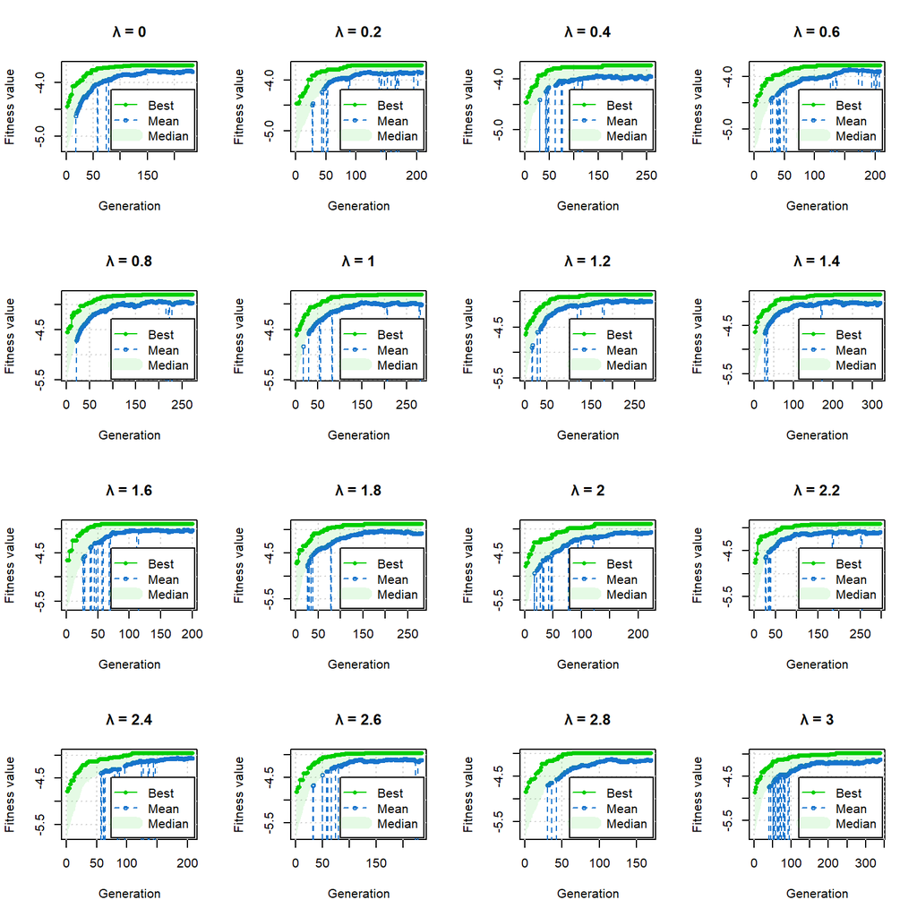

```r
par(mfrow = c(4, 4))
best[, {
  plot(ga[[1]], main = paste0('\u03bb = ', lambda))
}, by = lambda] %>%
  invisible()
```

**Figure S10**

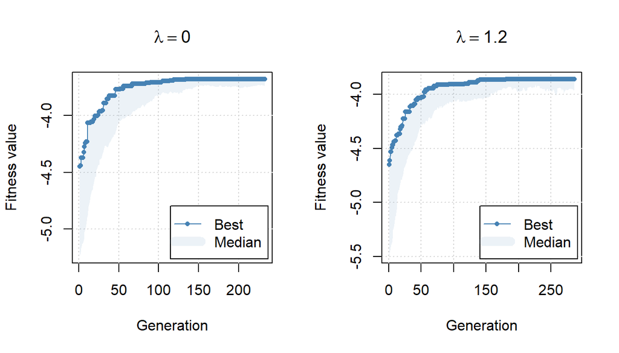

```r
par(mfrow = c(1, 2))
plot(
  best[lambda == 0, ga[[1]]],
  main = expression(lambda == 0),
  col = c('steelblue', NA, adjustcolor('steelblue', alpha.f = 0.1)))
plot(
  best[lambda == 1.2, ga[[1]]],
  main = expression(lambda == 1.2),
  col = c('steelblue', NA, adjustcolor('steelblue', alpha.f = 0.1)))
```

## Run final reconstructions and cross-validations from the selected inputs

```r
# Function to run reconstructions and cross-validation
reconstruct <- function(sol, lambda, pool, Xused, target, cvFolds) {

  pool <- pool[c(sol@solution) == 1]

  # Run cross validation to get R2, RE, and CE
  pcaOut <- lapply(seasons, function(s) {
    Qa <- target[s]
    X <- Xused[, pool[season == s, site2]]
    pcaModel <- prcomp(X, scale. = TRUE)
    PC <- pcaModel$x
    sv <- input_selection(PC[173:254, ], Qa$Qa, 'leaps backward', nvmax = 8)
    list(loadings = pcaModel$rotation[, sv, drop = FALSE],
         PC = PC[, sv, drop = FALSE])
  })

  pc3s <- lapply(pcaOut, '[[', 'PC')
  beta <- mb_par(target, pc3s, 1750, lambda = lambda, log.trans = 1:3)

  loadingList <- lapply(pcaOut, '[[', 'loadings')
  nPCs <- sapply(loadingList, ncol)
  interceptIdx <- c(1, nPCs[1] + 2, nPCs[1] + nPCs[2] + 3)

  beta2 <- beta[-interceptIdx]
  loadingMat <- as.matrix(Matrix:::.bdiag(loadingList))
  weight <- loadingMat %*% beta2

  rec <- mb_reconstruction(target, pc3s, 1750, lambda = lambda, log.trans = 1:3)
  cv <- cv_mb(target, pc3s, cvFolds, 1750,
              lambda = lambda,
              log.trans = 1:3,
              return.type = 'all')
  cv[, season := factor(season, seasons)]

  list(rec = list(rec),
       cv = list(cv[, -c('nRMSE', 'KGE')]),
       loadings = list(loadingList),
       beta = list(beta),
       weight = list(weight))
}

# Run the function for each lambda
set.seed(24)
cvFolds <- make_Z(1922:2003, nRuns = 50, frac = 0.25, contiguous = TRUE)

best[, c('rec', 'cv', 'loadings', 'beta', 'weight') :=
       reconstruct(ga[[1]], lambda, poolDT, Xrwdo, p1tar, cvFolds), by = lambda]

# Extract reconstructions
rec <- rbindlist(best$rec)
rec[, season := factor(season, seasons)]

# Extract CV scores
cv <- best[, cv[[1]], by = lambda]
cvLong <- melt(cv,
               id.vars = c('lambda', 'rep', 'season'),
               measure.vars = c('R2', 'RE', 'CE'),
               variable.name = 'metric')
```

Check if we get the correct f-value.

```r
merge(cv[, .(fnew = mean(fval)), by = lambda], best[, .(lambda, fval)], by = 'lambda')
```

```
##     lambda     fnew     fval
##  1:    0.0 3.679014 3.679014
##  2:    0.2 3.711764 3.711764
##  3:    0.4 3.723808 3.723808
##  4:    0.6 3.787130 3.787130
##  5:    0.8 3.793077 3.793077
##  6:    1.0 3.809312 3.809312
##  7:    1.2 3.859533 3.859533
##  8:    1.4 3.846040 3.846040
##  9:    1.6 3.892296 3.892296
## 10:    1.8 3.876829 3.876829
## 11:    2.0 3.892901 3.892901
## 12:    2.2 3.911734 3.911734
## 13:    2.4 3.949693 3.949693
## 14:    2.6 3.966613 3.966613
## 15:    2.8 3.980429 3.980429
## 16:    3.0 3.979361 3.979361
```

All is good.

Check PCA loadings (**Tables S2 to S7**)

```r
best[lambda == 0, loadings][[1]] %>%
  lapply(round, digits = 4)
```

```
## $NJ
##                  PC1     PC4     PC7
## MCC0          0.6004 -0.0098  0.1416
## PMTK1         0.4395  0.4601 -0.2301
## Laos pine2    0.2362  0.0037 -0.5159
## BDFH-1       -0.4159  0.2404 -0.1157
## Pha Taem0    -0.4144 -0.1294 -0.3543
## Phu Kradung0  0.0711 -0.5820  0.2291
## Laos pine1    0.1189 -0.4960  0.0222
## Phu Toei2     0.0133  0.1571  0.4642
## PMFH-1       -0.1630  0.3228  0.5035
##
## $JO
##                    PC1     PC8     PC9
## PMTK0           0.5258 -0.1292  0.3164
## MCC0            0.5345 -0.0832 -0.1001
## Chin Hills-2   -0.3054 -0.0735  0.2416
## Laos pine1      0.0933  0.0993  0.1851
## Phu Toei2      -0.0502  0.4552 -0.1498
## KHDF2           0.1351 -0.5299  0.0174
## KKFH-2          0.1520  0.1219  0.1289
## Wat Chan-1      0.1217  0.1455 -0.1905
## Laos pine-1     0.0750 -0.3786  0.0573
## MHS0           -0.1966 -0.4756 -0.1402
## MHS2           -0.1174  0.0758 -0.1957
## UPML1           0.4364  0.1011 -0.5137
## Salaeng Luong2 -0.1695 -0.2274 -0.6296
##
## $WY
##                PC1     PC5    PC11
## PMTK0       0.4988  0.0274 -0.1653
## MCC0        0.3727  0.3141  0.7527
## PKK0        0.4590  0.1885 -0.0440
## Laos pine1  0.0881 -0.4189 -0.0224
## Phu Toei2   0.0211  0.4463 -0.1495
## KHDF2       0.1622 -0.4580  0.1957
## Phu Toei0  -0.2788  0.1343  0.1016
## UPML0       0.4586 -0.0155 -0.5173
## Laos pine2  0.1389 -0.1539  0.0583
## Phu Toei-1 -0.1759  0.3317 -0.2311
## MHS-2       0.0591 -0.2701  0.0478
## QNFH-2      0.0210 -0.1556  0.0575
## MHS0       -0.1576 -0.1774 -0.0524
```

```r
best[lambda == 1.2, loadings][[1]] %>%
  lapply(round, digits = 4)
```

```
## $NJ
##                    PC1     PC5     PC8    PC13
## MCC0            0.4585  0.1256 -0.2445  0.5307
## PMTK1           0.3403  0.3327  0.0981  0.3460
## Phu Toei0      -0.3727  0.0123 -0.4643  0.0771
## Laos pine2      0.1038 -0.2538  0.2805  0.0374
## BDFH-1         -0.3231  0.0935 -0.0338 -0.1368
## Pha Taem0      -0.2665  0.1806  0.2365  0.2074
## PMTK0           0.4115 -0.0180 -0.0441 -0.5385
## Phu Kradung0    0.0282 -0.1732  0.6551 -0.0141
## PMFH0          -0.2247  0.1033  0.0589 -0.0963
## Salaeng Luong0  0.1151  0.1230 -0.2068 -0.1806
## Laos pine1      0.0242 -0.5592 -0.1189  0.0710
## MCC2            0.0099 -0.5288 -0.2571  0.1202
## PMFH-1         -0.2265  0.2945 -0.0306  0.0045
## MCC1            0.2511  0.1801 -0.1439 -0.4219
##
## $JO
##                    PC1     PC2     PC9
## PMTK0           0.4857 -0.3972  0.1152
## MCC0            0.4457 -0.4100 -0.2672
## Chin Hills-2   -0.3095 -0.0068  0.4083
## MCFH-1         -0.2420 -0.0123  0.1569
## Laos pine1      0.1514 -0.1424  0.3354
## KHDF2           0.0590 -0.4003  0.2424
## KKFH-2          0.3738  0.4903 -0.0672
## Laos pine-1     0.0923  0.0238  0.1548
## QNFH-2          0.4251  0.4415  0.0107
## MHS2           -0.1841 -0.2397 -0.4828
## Salaeng Luong2 -0.1478  0.0102 -0.5395
##
## $WY
##                  PC1
## PMTK0         0.5721
## MCC0          0.5158
## Chin Hills-2 -0.1898
## MCFH-1       -0.2380
## Laos pine1    0.2066
## KHDF2         0.1816
## Phu Toei0    -0.3870
## Laos pine2    0.2584
## MHS-2         0.1156
## KKFH-2        0.0914
```

# Results

## Skill scores as a function of λ

### Mean skill scores and Wilcoxon test

```r
cvMean <- cv[, lapply(.SD, mean), .SDcols = c('R2', 'RE', 'CE'), keyby = .(lambda, season)]
cvMeanLong <- cvMean %>% melt(id.var = c('lambda', 'season'), variable.name = 'metric')

cv0 <- cvLong[lambda == 0]

cvp <- cvLong[,
              .(p.value = {
                s <- .BY$season
                m <- .BY$metric
                wilcox.test(value, cv0[season == s & metric == m, value])$p.value
              }),
              by = .(lambda, season, metric)]
cvMeanMerged <- merge(cvMeanLong, cvp, by = c('lambda', 'season', 'metric')) %>%
  merge(cvMeanLong[lambda == 0, .(season, metric, v0 = value)], by = c('season', 'metric'))
```

**Figure 3**

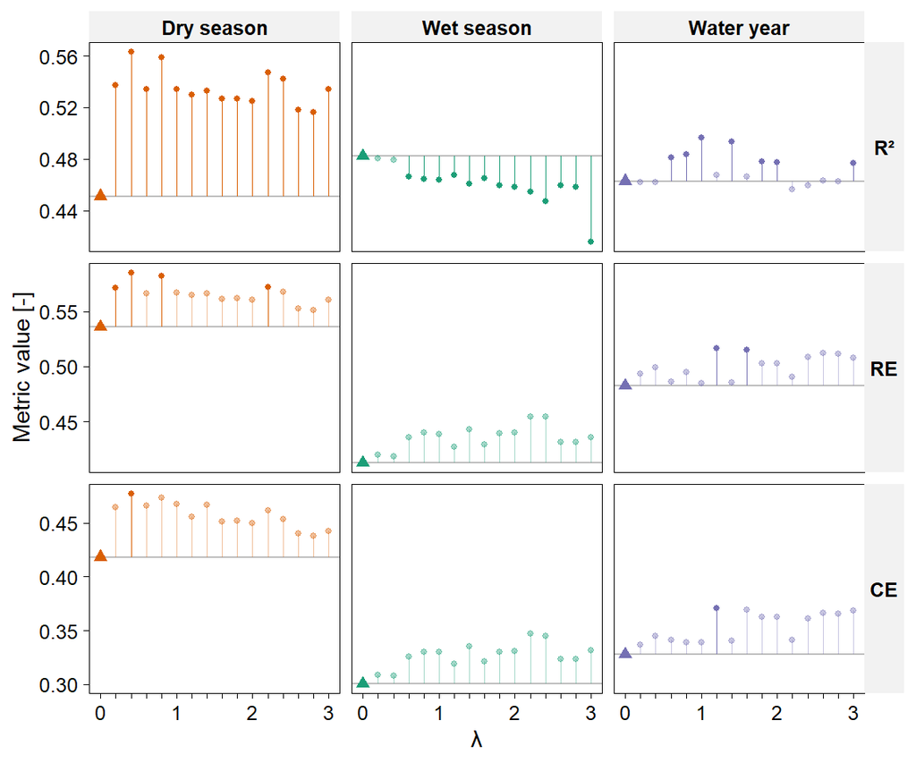

```r
ggplot(cvMeanMerged) +
  geom_hline(aes(yintercept = value), cvMeanLong[lambda == 0], colour = 'gray') +
  geom_linerange(
    aes(lambda, ymin = value, ymax = v0, colour = season, alpha = p.value < 0.1),
    size = 0.2) +
  geom_point(
    aes(lambda, value, colour = season, alpha = p.value < 0.1),
    size = 1) +
  geom_point(
    aes(lambda, value, colour = season),
    cvMeanLong[lambda == 0],
    shape = 'triangle',
    size = 2,
    alpha = 1) +
  facet_grid(
    vars(metric), vars(season),
    labeller = labeller(.rows = metricLab, .cols = ssnLabBrief),
    scales = 'free') +
  scale_alpha_manual(
    name = 'Significantly different from \u03bb = 0',
    values = c(0.4, 1)) +
  scale_colour_manual(values = dark2) +
  scale_x_continuous(breaks = seq(0, 3, 0.2), labels = skip_label(5)) +
  guides(color = FALSE) +
  labs(x= '\u03bb', y = 'Metric value [-]') +
  panel_border('black', 0.2) +
  theme(
    strip.text.y = element_text(angle = 0),
    legend.position = 'none')
```

### Skill distribution

**Figure S11**

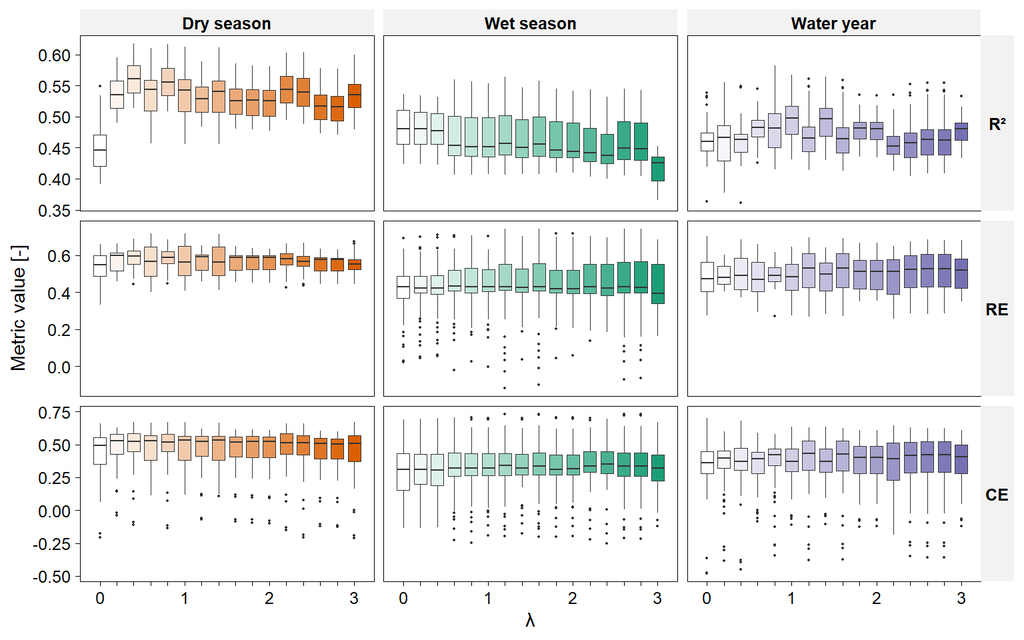

```r
ggplot(cvLong[lambda %in% round(seq(0, 3, 0.2), 1)]) +
  geom_boxplot(
    aes(lambda, value, group = lambda, fill = season, alpha = I(lambda / 3)),
    size = 0.2,
    outlier.size = 0.4, outlier.alpha = 1) +
  facet_grid(
    vars(metric), vars(season),
    labeller = labeller(.rows = metricLab, .cols = ssnLabBrief),
    scales = 'free') +
  scale_x_continuous(breaks = seq(0, 3, 0.2), labels = skip_label(5)) +
  scale_fill_manual(values = dark2) +
  panel_border('black', 0.2) +
  labs(x = '\u03bb', y = 'Metric value [-]') +
  theme(
    strip.text.y = element_text(angle = 0),
    legend.position = 'none')
```

## Trajectories

```r
# Make strings to merge to plot legend
lambdaLegendDT <- cvMean[, season := as.character(season)
                     ][, roundDT(.SD, digits = c(1, 2, 2, 2, 2), type = 'char')
                     ][, .(lab = paste(lambdaLab(.BY$lambda), R2, RE, CE, sep = '    ')), by = .(season, lambda)]


lambdaLegend <- function(s) {
  function(x) lambdaLegendDT[season == s & lambda %in% x, lab]
}
```

**Figure 4**

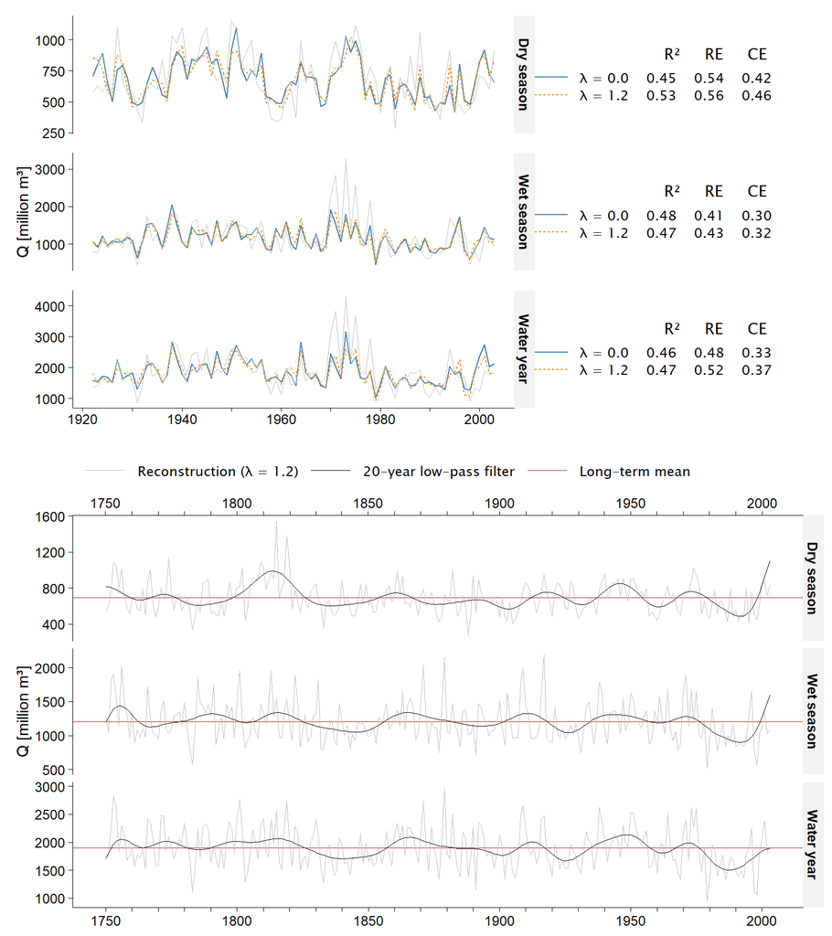

```r
# Select Model 1, apply low pass filter
recFinal <- rec[lambda == 1.2]
recFinal[, season := factor(season, seasons)]
recFinal[, Qlpf := dplR::pass.filt(Q, 20, 'low')]

p <- lapply(seasons, function(s) {
  ggplot(rec[season == s & year %in% 1922:2003 & lambda %in% c(0, 1.2)]) +
    geom_line(aes(year, Q, colour = to_char_1dp(lambda), linetype = to_char_1dp(lambda))) +
    geom_line(aes(year, Qa), p1tar[s], colour = 'gray', size = 0.2) +
    scale_linetype_discrete(
      name = c('          R\u00b2     RE     CE '),
      labels = lambdaLegend(s)) +
    scale_colour_manual(
      name = c('          R\u00b2     RE     CE '),
      values = c('steelblue', 'darkorange'),
      labels = lambdaLegend(s)) +
    scale_x_continuous(
      breaks = seq(1920, 2000, 10),
      labels = skip_label(2)) +
    labs(x = NULL,
         y = if (s == 'JO') 'Q [million m\u00b3]' else '') +
    facet_wrap(
      vars(season),
      strip.position = 'right',
      labeller = as_labeller(ssnLabBrief)) +
    theme(
      legend.title = element_text(hjust = 1, family = 'Lucida Sans Unicode'),
      legend.text = element_text(family = 'Lucida Sans Unicode'),
      axis.text.x = if (s != 'WY') element_blank(),
      axis.ticks.x = if (s != 'WY') element_blank(),
      axis.line.x = if (s != 'WY') element_blank(),
      strip.background = element_rect('gray95', NA),
      legend.box.margin = unit(c(0, 0, 0, -0.5), 'cm'),
      legend.key.width = unit(1, 'cm'))

})

trajPlotInst <- wrap_plots(p) + plot_layout(ncol = 1)

p <- ggplot(recFinal) +
  geom_hline(
    aes(yintercept = Qm, colour = 'Long-term mean'),
    recFinal[, .(Qm = mean(Q)), by = season],
    size = 0.2) +
  geom_line(aes(year, Q, colour = 'Reconstruction (\u03bb = 1.2)'), size = 0.2) +
  geom_line(aes(year, Qlpf, colour = '20-year low-pass filter'), size = 0.3) +
  facet_wrap(
    vars(season),
    scales = 'free_y',
    labeller = as_labeller(ssnLabBrief),
    strip.position = 'right',
    ncol = 1) +
  scale_x_continuous(
    breaks = seq(1750, 2000, 10),
    labels = skip_label(5),
    sec.axis = dup_axis()) +
  scale_colour_manual(
    name = NULL,
    values = c('gray', 'black', 'firebrick'),
    breaks = c('Reconstruction (\u03bb = 1.2)', '20-year low-pass filter', 'Long-term mean'),
  ) +
  labs(x = NULL, y = 'Q [million m\u00b3]') +
  theme(
    plot.margin = margin(t = 20),
    strip.background = element_rect('gray95', NA),
    legend.position = 'top',
    legend.key.width = unit(1.2, 'cm'),
    legend.text = element_text(family = 'Lucida Sans Unicode'))

trajPlotFull <- wrap_plots(p)

layout <- c(
  patchwork::area(1, 1,  30, 19),
  patchwork::area(31, 1, 60, 20)
)

wrap_plots(trajPlotInst) + wrap_plots(trajPlotFull) +
  plot_layout(design = layout)
```

## Magnitude of adjustments

**Figure S12**

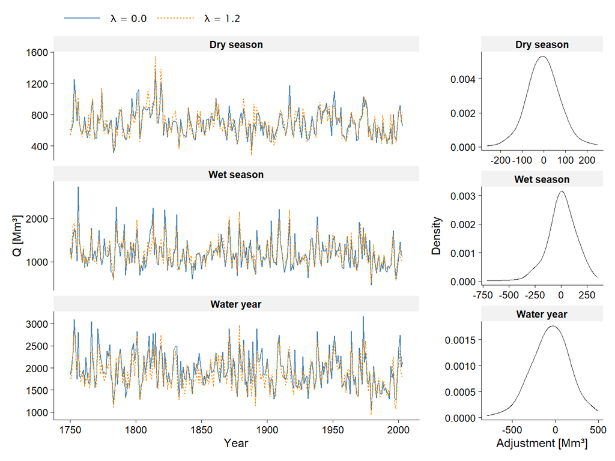

```r
# Amount of adjustment
adj <- rec[lambda %in% c(0, 1.2), dcast(.SD, season + year ~ lambda, value.var = 'Q')
         ][, adj := `1.2` - `0`]
# Density of adjustment amount
adjDens <- adj[, {
  s <- .BY$season
  bw <- fcase(s == 'NJ', 30,
              s == 'JO', 60,
              s == 'WY', 90)
  d <- density(adj, bw = bw, from = min(adj), to = max(adj))
  data.table(x = d$x, y = d$y)
}, by = season]

trajPlotFull2 <- ggplot(rec[lambda %in% c(0, 1.2)]) +
  geom_line(aes(year, Q, colour = to_char_1dp(lambda), linetype = to_char_1dp(lambda)), size = 0.4) +
  scale_linetype_discrete(
    name = NULL,
    label = lambdaLab) +
  scale_colour_manual(
    name = NULL,
    values = c('steelblue', 'darkorange'),
    labels = lambdaLab) +
  labs(x = 'Year',
       y = 'Q [Mm\u00b3]') +
  facet_wrap(vars(season), labeller = as_labeller(ssnLabBrief), ncol = 1, scales = 'free_y') +
  theme(
    legend.text = element_text(family = 'Lucida Sans Unicode'),
    legend.position = 'top',
    legend.key.width = unit(1.5, 'cm'),
    strip.background = element_rect('gray95', NA))

adjDensPlot <- ggplot(adjDens) +
  geom_line(aes(x, y), size = 0.2) +
  facet_wrap(vars(season), scales = 'free', ncol = 1, labeller = as_labeller(ssnLabBrief)) +
  theme(strip.background = element_rect('gray95', NA)) +
  labs(x = 'Adjustment [Mm\u00b3]', y = 'Density')

trajPlotFull2 + adjDensPlot +
  plot_layout(widths = c(3, 1))
```

## Flow ratio

**Figure 5**

```r
p1tarWide <- dcast(p1tar, year ~ season, value.var = 'Qa')
p1tarWide[, rQ := NJ / WY]

deltaQ <- rec[, dcast(.SD, lambda + year ~ season, value.var = 'Q')
            ][, dQ := NJ + JO - WY
            ][, rQ := NJ / WY]
densEst <- deltaQ[, {
  d <- density(dQ, cut = 0)
  data.table(x = d$x, y = d$y)
}, by = lambda]
Qmean <- p1tar[season == 'WY', mean(Qa)]
```

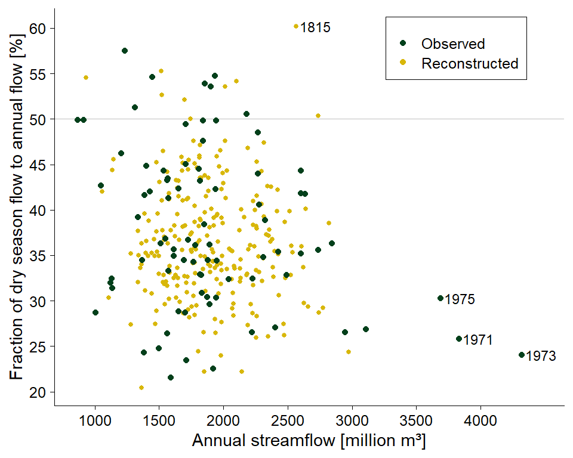

```r
ggplot(deltaQ[lambda == 1.2], aes(WY, rQ * 100)) +
  geom_hline(yintercept = 50, colour = 'gray', size = 0.2) +
  geom_point(aes(colour = 'Reconstructed'), size = 1) +
  geom_point(aes(colour = 'Observed'), p1tarWide) +
  geom_text(
    aes(label = year),
    p1tarWide[year %in% c(1971, 1973, 1975)],
    size = 3,
    nudge_x = 150) +
  geom_text(
    aes(label = year),
    deltaQ[lambda == 1.2 & year == 1815],
    size = 3,
    nudge_x = 150) +
  scale_colour_manual(
    name = NULL,
    values = pal) +
  scale_y_continuous(breaks = seq(20, 60, 5)) +
  scale_x_continuous(breaks = seq(1000, 4000, 500)) +
  labs(
    x = 'Annual streamflow [million m\u00b3]',
    y = 'Fraction of dry season flow to annual flow [%]') +
  theme(
    legend.margin = margin(5, 5, 5, 5),
    legend.background = element_rect(NA, 'black', 0.2),
    legend.position = c(0.65, 0.9))
```

## Selected inputs

Extract selected inputs

```r
weightDT <- best[lambda %in% c(0, 1.2), {
  DT <- poolDT[c(ga[[1]]@solution == 1)]
  DT[, prox := fifelse(site %in% crnMeta$site, 'RW', 'OX')]
  DT[, site.display := paste0(siteLab(site), ' ', prox, ' (', lag, ')')]
  DT[, weight := weight]
  DT[]
}, by = lambda]

weightDT[, site.display :=
           factor(site.display,
                  levels = sort(unique(site.display), decreasing = TRUE))]

weightDT[, sameSign := fifelse(weight * rho < 0, 'x', ' ')]

count <-weightDT[, .N, by = .(season, lambda)]
```

**Figure 6**

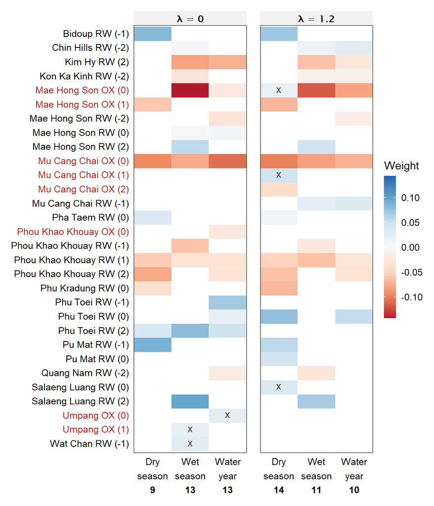

```r
yLabCol <- function(x) {
  sapply(x, function(xx) {
    ind <- grep('RW', xx)
    if (length(ind) == 0) xx <- paste0(ind, '<span style="color:firebrick">', xx, '</span>')
    xx
  })
}
ssnLab2Lines <- function(l) {
  n <- count[lambda == l, N]
  function(s) {
    out <- fcase(
      s == 'NJ', 'Dry<br>season',
      s == 'JO', 'Wet<br>season',
      default = 'Water<br>year')
    paste0(out, '<br>**', n, '**')
  }
}

pl <- lapply(c(0, 1.2), function(l) {
  ggplot(weightDT[lambda == l]) +
    geom_tile(aes(season, site.display, fill = weight)) +
    geom_text(
      aes(season, site.display, label = sameSign),
      vjust = 0.25,
      colour = 'gray30') +
    facet_wrap(vars(lambda), labeller = as_labeller(lambdaLab)) +
    scale_x_discrete(labels = ssnLab2Lines(l), expand = c(0, 0)) +
    scale_y_discrete(labels = yLabCol, drop = FALSE) +
    scale_fill_distiller(
      palette = 'RdBu',
      direction = 1,
      name = 'Weight',
      limits = abs_range(weightDT$weight)) +
    labs(x = NULL, y = NULL) +
    cowplot::panel_border('black', 0.2) +
    theme(
      legend.key.height = unit(1, 'cm'),
      axis.text.y = element_markdown(),
      axis.text.x = element_markdown(lineheight = 1.5),
      strip.text = element_text(family = 'Lucida Sans Unicode', face = 'bold'),
      axis.ticks = element_blank())
})

for (i in 2:length(pl)) pl[[i]] <- pl[[i]] + theme(axis.text.y = element_blank())

wrap_plots(pl, nrow = 1, guides = 'collect')
```

## Annual mass balance

**Figure 7**

```r
densEst <- deltaQ[, {
  d <- density(dQ, cut = 0, bw = if (lambda == 0) 120 else 100)
  data.table(x = d$x, y = d$y)
}, by = lambda]

densEst[, yScaled := y / max(y) * 3]
densEst[, l2 := to_char_1dp(lambda)]
```

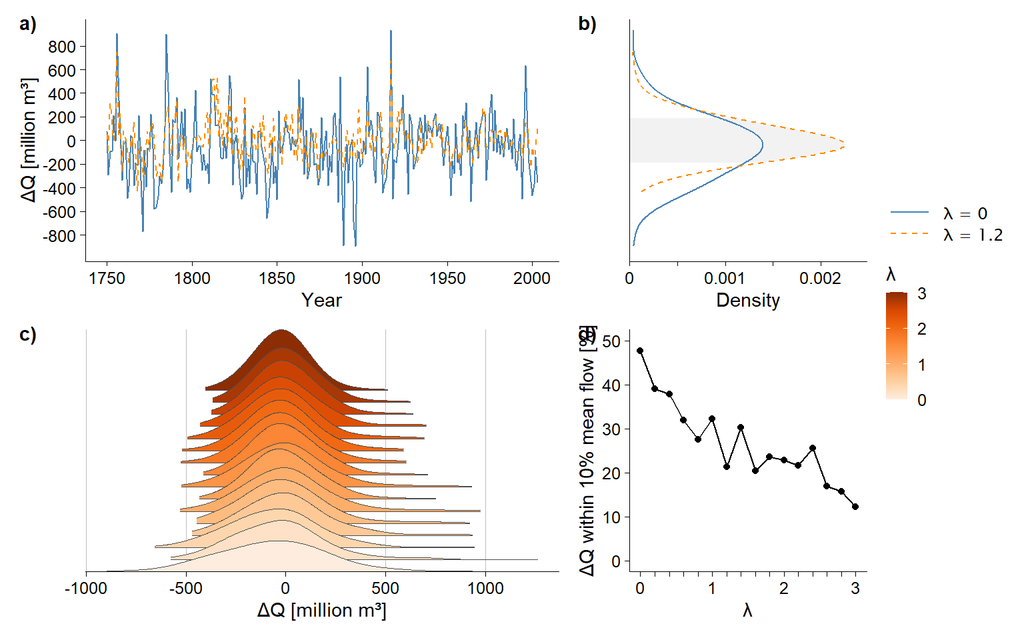

```r
dQlims <- abs_range(densEst[lambda %in% c(0, 1.2), x])
p1 <- ggplot(deltaQ[lambda %in% c(0, 1.2)]) +
  geom_line(aes(year, dQ, colour = as.character(lambda), linetype = as.character(lambda)), size = 0.4) +
  scale_y_continuous(
    breaks = seq(-800, 800, 200),
    limits = dQlims) +
  scale_colour_manual(
    name = NULL,
    values = c('steelblue', 'darkorange'),
    labels = lambdaLab) +
  scale_linetype_manual(
    name = NULL,
    labels = lambdaLab,
    values = c(1, 2)) +
  labs(x = 'Year', y = '\u0394Q [million m\u00b3]') +
  theme(legend.position = 'none')

p2 <- ggplot(densEst[lambda %in% c(0, 1.2)]) +
  geom_area(
    aes(x, y),
    densEst[x %between% c(-Qmean / 10, Qmean / 10) & lambda == 1.2],
    fill = 'gray95') +
  geom_line(aes(x, y, colour = as.character(lambda), linetype = as.character(lambda))) +
  scale_colour_manual(
    name = NULL,
    values = c('steelblue', 'darkorange'),
    labels = lambdaLab) +
  scale_x_continuous(
    breaks = seq(-1000, 1000, 200),
    limits = dQlims) +
  scale_y_continuous(expand = expansion(c(0, 0.1), 0), labels = skip_label(2)) +
  scale_linetype_manual(
    name = NULL,
    labels = lambdaLab,
    values = c(1, 2)) +
  coord_flip() +
  labs(x = NULL, y = 'Density') +
  theme(
    legend.key.width = unit(0.95, 'cm'),
    legend.text = element_text(family = 'Lucida Sans Unicode'),
    axis.text.y = element_blank(),
    axis.ticks.y = element_blank())

lambdas <- round(seq(0, 3, 0.2), 1)

p3 <- ggplot(densEst[lambda %in% lambdas]) +
  geom_ribbon(
    aes(x,
        ymin = lambda * 3,
        ymax = yScaled + lambda * 3,
        group = rev(l2),
        fill = lambda),
    colour = 'gray30',
    size = 0.2) +
  scale_fill_distiller(
    name = '\u03bb',
    palette = 'Oranges', direction = 1) +
  scale_y_continuous(expand = c(0, 0)) +
  labs(x = '\u0394Q [million m\u00b3]') +
  theme(
    panel.grid.major.x = element_line('gray'),
    axis.text.y = element_blank(),
    axis.line.y = element_blank(),
    axis.ticks.y = element_blank())

p4 <- ggplot(
  deltaQ[lambda %in% lambdas, .(p = .SD[abs(dQ) > Qmean / 10, .N] / .N * 100,
           min = min(dQ),
           max = max(dQ)),
       by = lambda]) +
  geom_line(aes(lambda, p)) +
  geom_point(aes(lambda, p)) +
  scale_x_continuous(breaks = seq(0, 3, 0.2), labels = skip_label(5)) +
  scale_y_continuous(limits = c(0, 50)) +
  labs(x = '\u03bb', y = '\u0394Q within 10% mean flow [%]')

p1 + p2 + p3 + p4 +
  plot_layout(ncol = 2, widths = c(2, 1), guides = 'collect') +
  plot_annotation(tag_levels = 'a', tag_suffix = ')')
```

# References

Nguyen, H. T. T., Galelli, S., Xu, C., & Buckley, B. M. (2020). Multi-Proxy, Multi-Season Streamflow Reconstruction with Mass Balance Adjustment. Earth and Space Science Archive. https://doi.org/10.1002/essoar.10504791.1

Cook, B. I., & Buckley, B. M. (2009). Objective determination of monsoon season onset, withdrawal, and length. Journal of Geophysical Research, 114(D23), D23109. https://doi.org/10.1029/2009JD012795

Gudmundsson, L., Bremnes, J. B., Haugen, J. E., & Engen-Skaugen, T. (2012). Technical Note: Downscaling RCM precipitation to the station scale using statistical transformations – a comparison of methods. Hydrology and Earth System Sciences, 16(9), 3383–3390. https://doi.org/10.5194/hess-16-3383-2012

Gudmundsson, L. (2016). qmap: Statistical transformations for post-processing climate model output. R package version 1.0-4.

Harris, I., Osborn, T. J., Jones, P., & Lister, D. (2020). Version 4 of the CRU TS monthly high-resolution gridded multivariate climate dataset. Scientific Data, 7(1), 109. https://doi.org/10.1038/s41597-020-0453-3